# Practica_3

Omar Rojas/Edwin Rivera

2023-04-24

### PREGUNTA 1 - Apartado 1

Descomprimir el fichero comprimido que contiene los registros del servidor, y a partir de los datos extraídos, cargar en data frame los registros con las peticiones servidas.

```
##       IP             Timestamp           Recurso           Cod_retorno
##  Length:47748       Length:47748       Length:47748       Min.   :200.0
##  Class :character   Class :character   Class :character   1st Qu.:200.0
##  Mode  :character   Mode  :character   Mode  :character   Median :200.0
##                                                           Mean   :227.1
##                                                           3rd Qu.:200.0
##                                                           Max.   :501.0
##      Tamaño        Metodo_limpio Protocolo_limpio
##  Min.   :      0   GET :46020    HTTP/0.2:    1
##  1st Qu.:    124   HEAD:  106    HTTP/1.0:47747
##  Median :    974   POST: 1622
##  Mean   :   6531
##  3rd Qu.:   2788
##  Max.   :4816896
```

### PREGUNTA 1 Apartado 2

Identificar el número único de usuarios que han interactuado directamente con el servidor de forma segregada según si los usuarios han tenido algún tipo de error en las distintas peticiones ofrecidas por el servidor.

```
## [1] 200 302 304 400 403 404 500 501
## Levels: 200 302 304 400 403 404 500 501
```

```
## [1] 2296
```

```
## [1] 970
```

```
## [1] 505
```

```
## [1] 1
```

```
## [1] 5
```

```
## [1] 152
```

```
## [1] 29
```

```
## [1] 11
```

### PREGUNTA 1 Apartado 3

| http | frecuencia_http |
| --- | --- |
| GET | 46020 |
| HEAD | 106 |
| POST | 1622 |

### PREGUNTA 1 Apartado 4

Generar un gráfico que permita visualizar las respuestas del servidor, es decir, la distribución de peticiones según el código de respuesta de esta. Probad distintos tipos de gráficos (por lo menos 2 distintos e incluid estos en el documento RMarkdown).

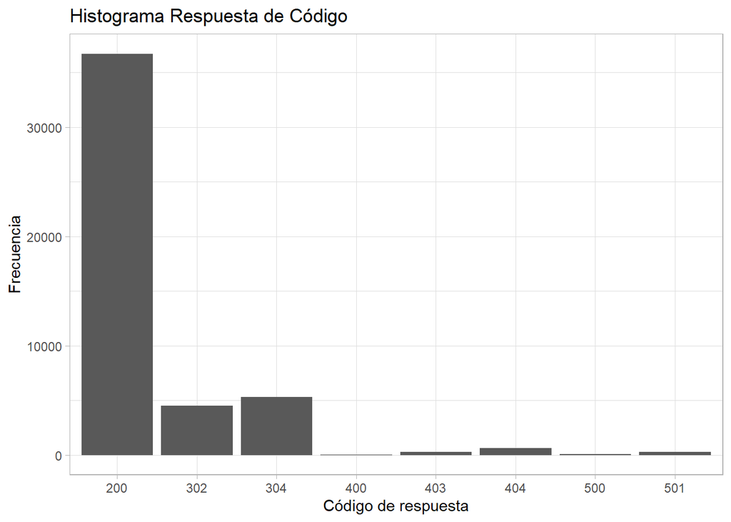

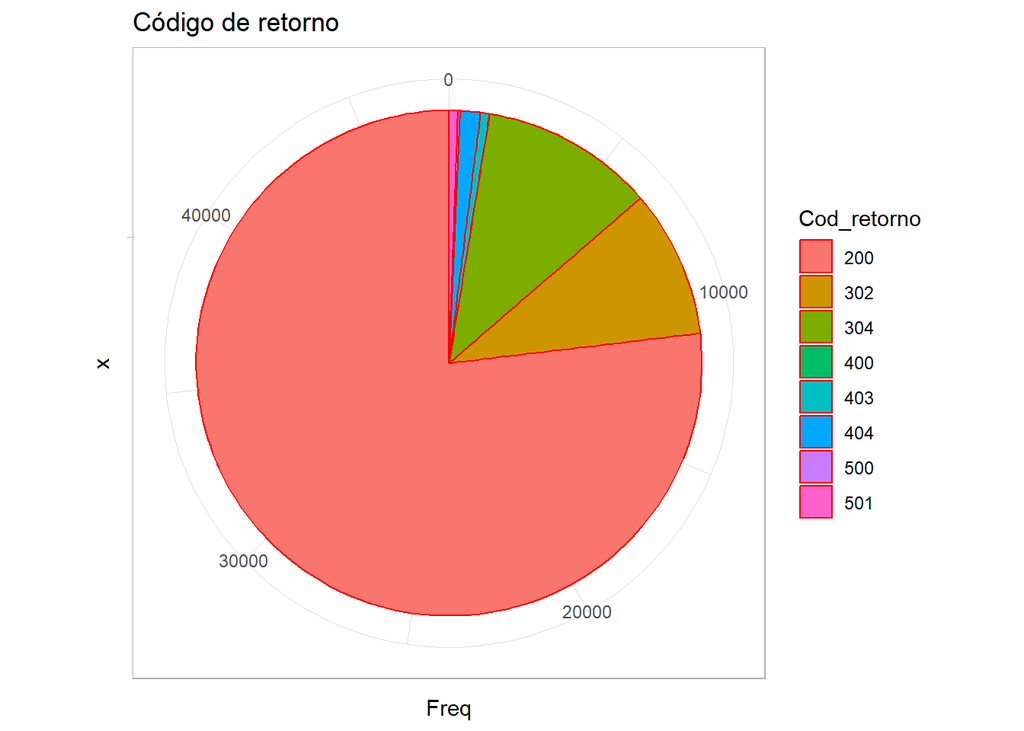

### PREGUNTA 1 Apartado 5

Utilizando un algoritmo de aprendizaje no supervisado, realizad un análisis de clústering con k-means para los datos del servidor.

```
## K-means clustering with 2 clusters of sizes 60, 47688
##
## Cluster means:
##   Cod_retorno      Tamaño Metodo_limpio_GET Metodo_limpio_HEAD
## 1     200.000 1480950.217         1.0000000        0.000000000
## 2     227.144    4676.375         0.9637645        0.002222781
##   Metodo_limpio_POST Protocolo_limpio_HTTP/0.2 Protocolo_limpio_HTTP/1.0
## 1         0.00000000              0.000000e+00                  1.000000
## 2         0.03401275              2.096964e-05                  0.999979
##   Longitud_Url
## 1     51.93333
## 2     35.65123
##
## Clustering vector:
##     [1] 2 2 2 2 2 2 2 2 2 2 2 2 2 2 2 2 2 2 2 2 2 2 2 2 2 2 2 2 2 2 2 2 2 2 2 2
```

[output cut: 1335 more lines]

```
## K-means clustering with 4 clusters of sizes 52, 115, 1960, 45621
##
## Cluster means:
##   Cod_retorno      Tamaño Metodo_limpio_GET Metodo_limpio_HEAD
## 1    200.0000 1578307.769         1.0000000        0.000000000
## 2    200.0000  392356.191         0.9739130        0.000000000
## 3    200.0000   46493.648         0.7163265        0.000000000
## 4    228.3739    2050.448         0.9743758        0.002323491
##   Metodo_limpio_POST Protocolo_limpio_HTTP/0.2 Protocolo_limpio_HTTP/1.0
## 1         0.00000000              0.000000e+00                 1.0000000
## 2         0.02608696              0.000000e+00                 1.0000000
## 3         0.28367347              0.000000e+00                 1.0000000
## 4         0.02330067              2.191973e-05                 0.9999781
##   Longitud_Url
## 1     54.57692
```

[output cut: 1341 more lines]

### PREGUNTA 1 Apartado 6

Representad visualmente en gráficos de tipo scatter plot el resultado de vuestros clústering.

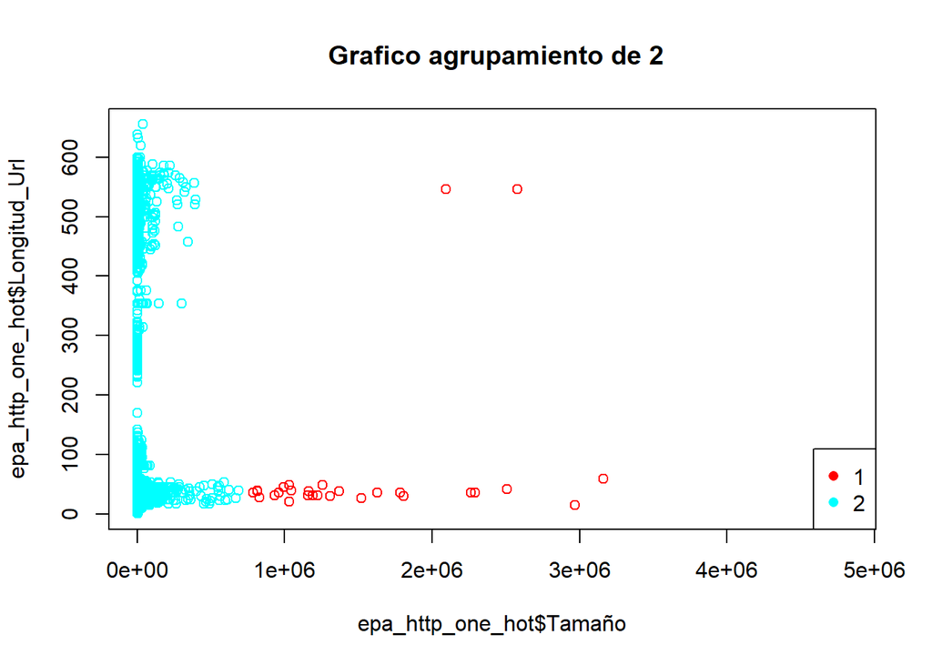

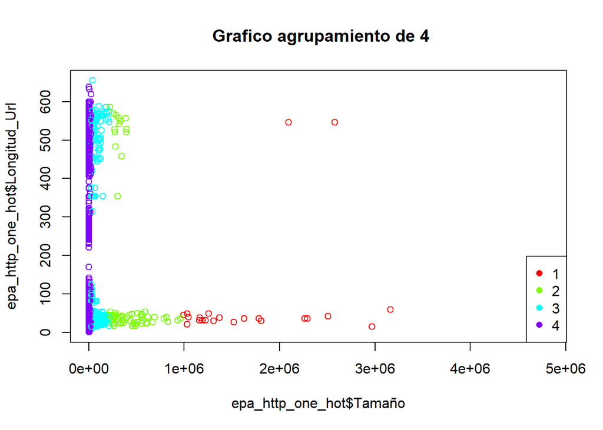

## R Markdown

[output not shown]